# Capstone Milestone Project

tndl

04 January 2021

#Capstone Milestone Project

## Introduction

This document aims to explain some features from the English Twitter, blogs and news datasets by providing a basic report of the datasets. * Culled from Coursera Capstone Project from the Data Science Specialization

Link to GitHub: https://github.com/ThandoNdl/datasciencecoursera/blob/master/PML%20Report.Rmd

## Data Preparation

### Load the data

```r
load_data = function(file_name){

  con = file(file_name, "r")
  text_file = readLines(con, encoding = "UTF-8", skipNul = TRUE, warn = FALSE)
  # Load the data as a corpus
  text_doc <- Corpus(VectorSource(text_file))
  close(con)

  return(text_doc)
}

twitter = load_data("en_US.twitter.txt")
blogs = load_data("en_US.blogs.txt")
news = load_data("en_US.news.txt")
```

## Basic Analysis

### Split Data

Since the sets were quite big, we are going to split them into a training, validation and testing set for both analysis and modeling purposes.

60% of the data will be used for training  
20% of the data will be used for validation  
20% of the data will be used for testing

### Data Cleaning

Some basic data cleaning was performed on the text to remove multiple spaces, ensure all letters are in the same case, remove numbers and punctuation, as well as removing some common English stopwords, for example, articles.

```r
text_clean = function(data){

  clean_text <- Corpus(VectorSource(data))

# Cleaning corpus
  clean_text <- tm_map(clean_text, stripWhitespace)
  clean_text <- tm_map(clean_text, content_transformer(tolower))
  clean_text <- tm_map(clean_text, removeNumbers)
  clean_text <- tm_map(clean_text, removePunctuation)
  clean_text <- tm_map(clean_text, removeWords, stopwords("english"))

  return(clean_text)
}

twitter_clean = text_clean(twitter_split$Train)
blogs_clean = text_clean(blogs_split$Train)
news_clean = text_clean(news_split$Train)
```

### Bag of Words

Word counts are calculated and graphs of the 10 most common words will be shown.

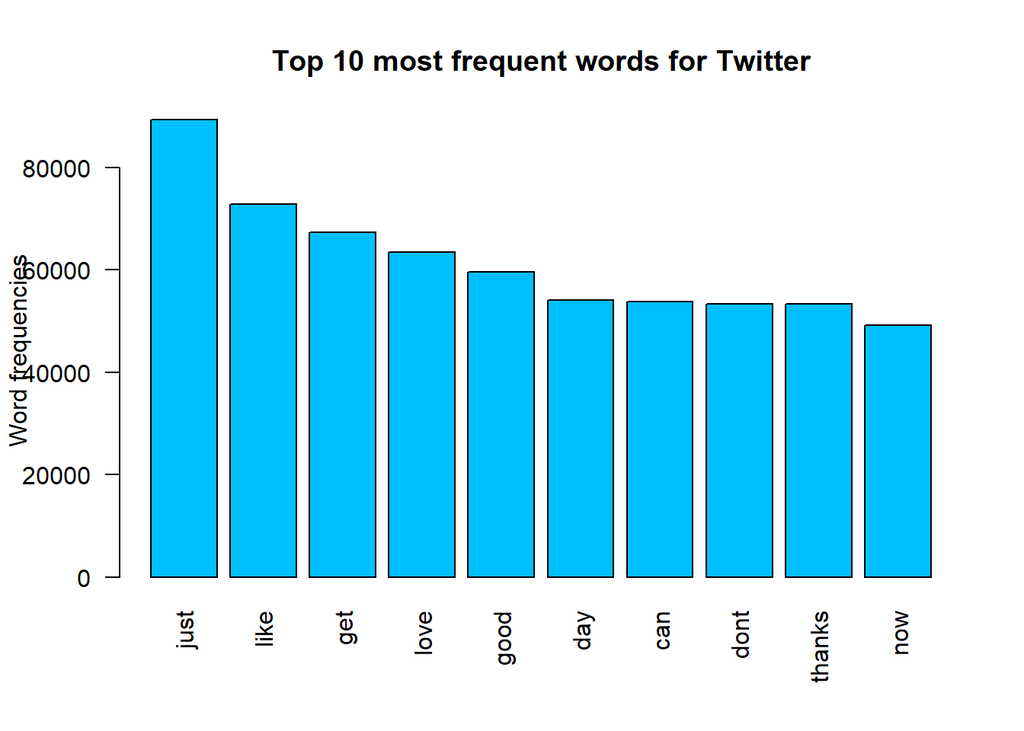

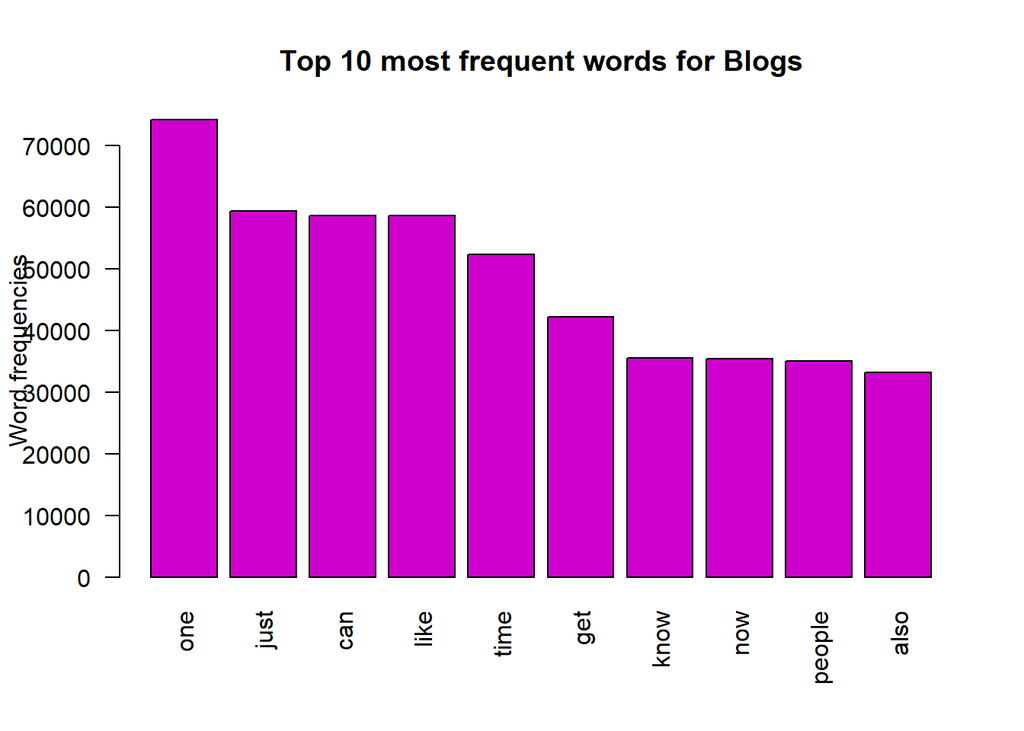

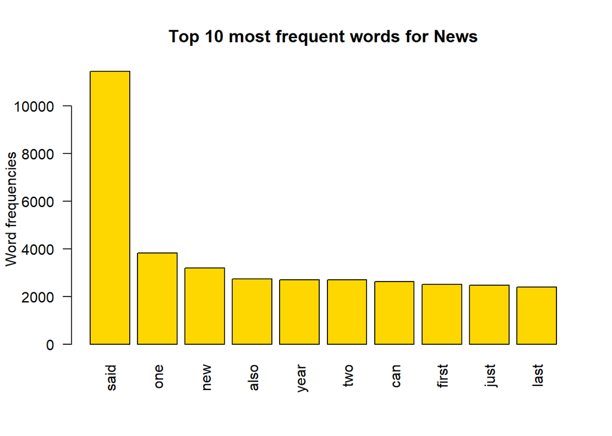

#### Word clouds

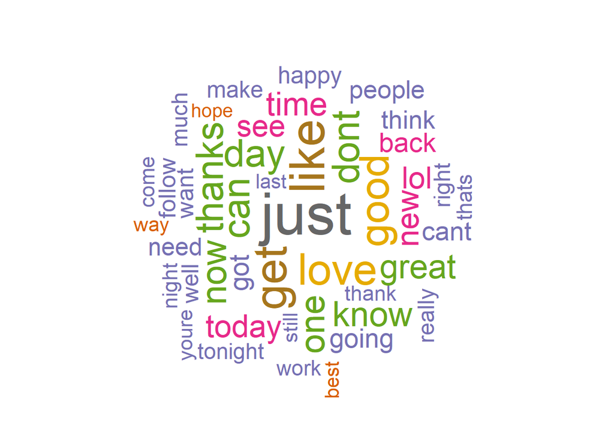

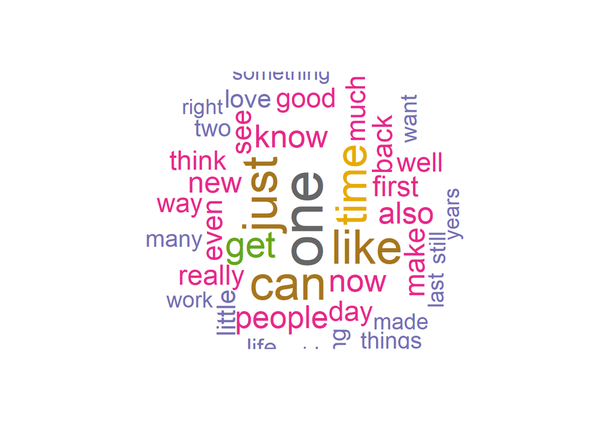

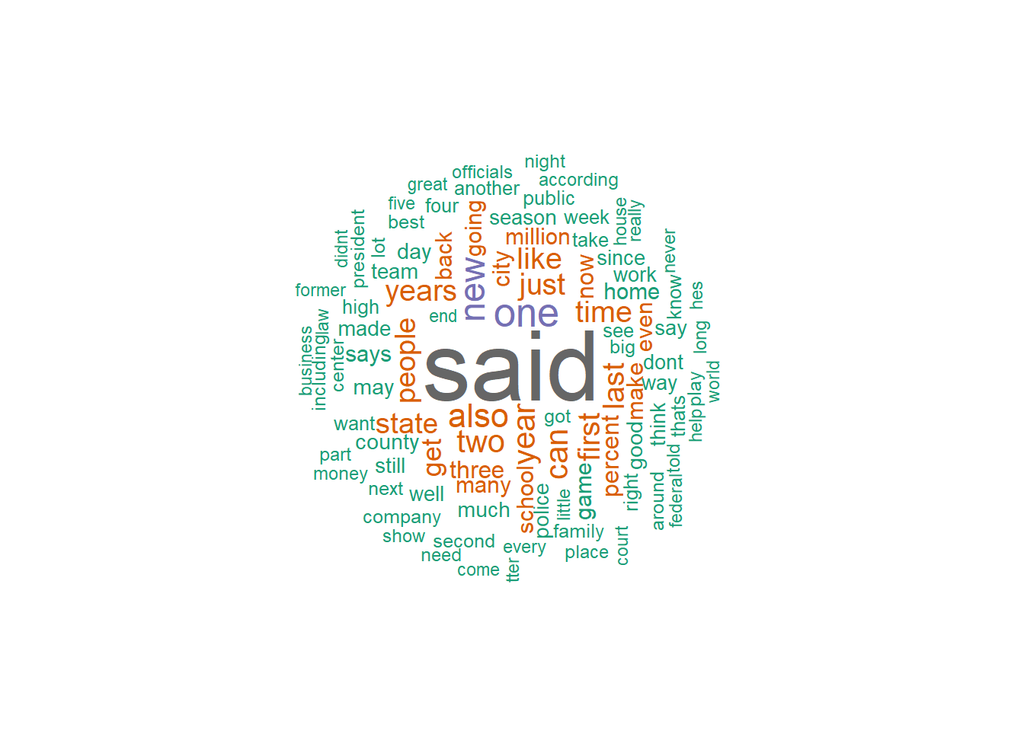

### String Summary

Below is the summaries of the text files

##### Twitter String Summary

```
## Chars:       73747700
## Letters:     55474714
## Whitespace:  18225076
## Punctuation: 47906
## Digits:      0
## Words:       10413013
## Sentences:   0
## Lines:       1
## Wordlens:    158413 398906 474822 510968 677779 1140287 1286664 1366442 1828826 2569906
##              1 1 1 1 1 1 1 1 1 1
## Senlens:     0
##              10
## Syllens:     1444 1747 3442 6477 18210 86289 405966 1214254 3842527 4490410
##              1 1 1 1 1 1 1 1 1 1
```

##### Blogs String Summary

```
## Chars:       90774031
## Letters:     67945681
## Whitespace:  22379453
## Punctuation: 448896
## Digits:      0
## Words:       11642140
## Sentences:   0
## Lines:       1
## Wordlens:    109233 246767 679731 885602 994764 1058578 1475143 1765724 2040992 2385606
##              1 1 1 1 1 1 1 1 1 1
## Senlens:     0
##              10
## Syllens:     601 1120 1380 3750 22493 151564 687102 1945893 3970747 4593782
##              1 1 1 1 1 1 1 1 1 1
```

##### News String Summary

```
## Chars:       7186587
## Letters:     5587844
## Whitespace:  1586470
## Punctuation: 12273
## Digits:      0
## Words:       906804
## Sentences:   0
## Lines:       1
## Wordlens:    7085 13276 63489 66329 82499 91504 127711 142692 148396 163823
##              1 1 1 1 1 1 1 1 1 1
## Senlens:     0
##              10
## Syllens:     34 38 104 376 1941 14285 61678 179128 274559 359047
##              1 1 1 1 1 1 1 1 1 1
```

## Next Steps

Further exploratory analysis will have to be done. It would be interesting to see if phrases or strings of words occur frequently.

### n-gram

An n-gram is simply any sequence of n words which helps capture more context around each word.

Below are the 2 word phrases that appear most frequently.

##### Twitter 2-gram

```
##              ngrams  freq         prop
## 1        cant wait  10036 0.0009637941
## 2        right now   9912 0.0009518860
## 3       last night   6750 0.0006482274
## 4  looking forward   5399 0.0005184859
## 5        dont know   5227 0.0005019681
## 6   happy birthday   5019 0.0004819931
## 7     good morning   4686 0.0004500139
## 8         im going   4513 0.0004334001
## 9         just got   4378 0.0004204355
## 10       feel like   4097 0.0003934500
```

##### Blogs 2-gram

```
##          ngrams freq         prop
## 1    years ago  3091 0.0002655010
## 2     new york  2956 0.0002539052
## 3    right now  2942 0.0002527027
## 4  even though  2799 0.0002404197
## 5    feel like  2577 0.0002213511
## 6      can see  2551 0.0002191178
## 7   first time  2544 0.0002185165
## 8    last year  2409 0.0002069207
## 9    make sure  2366 0.0002032273
## 10   dont know  2265 0.0001945519
```

##### News 2-gram

```
##          ngrams freq         prop
## 1    last year   596 0.0006572541
## 2     new york   488 0.0005381544
## 3  high school   401 0.0004422129
## 4     st louis   398 0.0004389046
## 5   new jersey   353 0.0003892797
## 6    years ago   315 0.0003473742
## 7    last week   301 0.0003319354
## 8  los angeles   247 0.0002723855
## 9       said “   232 0.0002558439
## 10   two years   224 0.0002470217
```

Below are the 3 word phrases that appear most frequently.

##### Twitter 3-gram

```
##                     ngrams freq         prop
## 1       happy mothers day  1944 1.866895e-04
## 2           cant wait see  1877 1.802553e-04
## 3             let us know  1342 1.288772e-04
## 4          happy new year  1002 9.622577e-05
## 5          im pretty sure   645 6.194174e-05
## 6           cinco de mayo   577 5.541145e-05
## 7          dont even know   524 5.032166e-05
## 8  looking forward seeing   491 4.715255e-05
## 9            feel like im   467 4.484774e-05
## 10          cant wait get   466 4.475171e-05
```

##### Blogs 3-gram

```
##                         ngrams freq         prop
## 1               new york city   455 3.908217e-05
## 2              new york times   364 3.126573e-05
## 3     vested interests vested   251 2.155961e-05
## 4  interests vested interests   251 2.155961e-05
## 5         amazon services llc   241 2.070067e-05
## 6            couple weeks ago   241 2.070067e-05
## 7                 new york ny   237 2.035709e-05
## 8              im pretty sure   215 1.846740e-05
## 9               two years ago   214 1.838150e-05
## 10        incorporated item c   202 1.735076e-05
```

##### News 3-gram

```
##                     ngrams freq         prop
## 1  president barack obama    64 7.057770e-05
## 2           new york city    54 5.954993e-05
## 3           two years ago    51 5.624161e-05
## 4         st louis county    42 4.631662e-05
## 5      gov chris christie    39 4.300829e-05
## 6        first time since    34 3.749440e-05
## 7            world war ii    29 3.198052e-05
## 8             g protein g    27 2.977497e-05
## 9                 g fat g    26 2.867219e-05
## 10          two weeks ago    26 2.867219e-05
```

After further explorations, one would have to build a predictive model on the data to predict the next word.